# Final Exam

Reginald Mordi

December 1, 2020

```r
library(class)
library(caret)
library(ISLR)
library(dummies)
library(FNN)
library(dplyr)
library(ggvis)
```

```r
library(ggplot2)
library(e1071)
```

```r
library(tidyverse)
library(factoextra)
library(flexclust)
library(imputeTS)
library(stats)
```

### Reading Data

```r
#Read Data
Data <- read.csv("BathSoap.csv")

Soap_Data <- Data
```

### Understanding Data

```r
summary(Soap_Data)
```

```
##    Member.id            SEC            FEH              MT
##  Min.   :1010010   Min.   :1.00   Min.   :0.000   Min.   : 0.000
##  1st Qu.:1065295   1st Qu.:1.75   1st Qu.:1.000   1st Qu.: 4.000
##  Median :1106235   Median :2.50   Median :3.000   Median :10.000
##  Mean   :1104188   Mean   :2.50   Mean   :2.048   Mean   : 8.178
##  3rd Qu.:1148293   3rd Qu.:3.25   3rd Qu.:3.000   3rd Qu.:10.000
##  Max.   :1167670   Max.   :4.00   Max.   :3.000   Max.   :19.000
##       SEX             AGE             EDU              HS
##  Min.   :0.000   Min.   :1.000   Min.   :0.000   Min.   : 0.000
##  1st Qu.:2.000   1st Qu.:3.000   1st Qu.:3.000   1st Qu.: 3.000
##  Median :2.000   Median :3.000   Median :4.500   Median : 4.000
##  Mean   :1.738   Mean   :3.213   Mean   :4.043   Mean   : 4.192
##  3rd Qu.:2.000   3rd Qu.:4.000   3rd Qu.:5.000   3rd Qu.: 5.000
##  Max.   :2.000   Max.   :4.000   Max.   :9.000   Max.   :15.000
##      CHILD             CS         Affluence.Index No..of.Brands
##  Min.   :1.000   Min.   :0.0000   Min.   : 0.00   Min.   :1.000
##  1st Qu.:2.000   1st Qu.:1.0000   1st Qu.:10.00   1st Qu.:2.000
##  Median :4.000   Median :1.0000   Median :15.00   Median :3.000
##  Mean   :3.233   Mean   :0.9317   Mean   :17.02   Mean   :3.637
##  3rd Qu.:4.000   3rd Qu.:1.0000   3rd Qu.:24.00   3rd Qu.:5.000
##  Max.   :5.000   Max.   :2.0000   Max.   :53.00   Max.   :9.000
##    Brand.Runs     Total.Volume   No..of..Trans        Value
##  Min.   : 1.00   Min.   :  150   Min.   :  1.00   Min.   :  20.0
##  1st Qu.: 8.00   1st Qu.: 6825   1st Qu.: 22.00   1st Qu.: 789.6
##  Median :15.00   Median :10360   Median : 28.00   Median :1216.0
##  Mean   :15.75   Mean   :11915   Mean   : 31.15   Mean   :1337.4
##  3rd Qu.:21.00   3rd Qu.:15344   3rd Qu.: 40.00   3rd Qu.:1675.8
##  Max.   :74.00   Max.   :50895   Max.   :138.00   Max.   :6371.9
##  Trans...Brand.Runs    Vol.Tran         Avg..Price    Pur.Vol.No.Promo....
##  Min.   : 1.000     Min.   :  94.43   Min.   : 5.62   Length:600
##  1st Qu.: 1.420     1st Qu.: 250.51   1st Qu.: 9.76   Class :character
##  Median : 1.845     Median : 361.52   Median :11.25   Mode  :character
##  Mean   : 2.618     Mean   : 415.05   Mean   :11.83
##  3rd Qu.: 2.690     3rd Qu.: 490.89   3rd Qu.:13.42
##  Max.   :23.000     Max.   :2525.00   Max.   :33.33
##  Pur.Vol.Promo.6..  Pur.Vol.Other.Promo.. Br..Cd..57..144     Br..Cd..55
##  Length:600         Length:600            Length:600         Length:600
##  Class :character   Class :character      Class :character   Class :character
##  Mode  :character   Mode  :character      Mode  :character   Mode  :character
##
```

[output cut: 29 more lines]

```
##
##   PropCat.10         PropCat.11         PropCat.12         PropCat.13
##  Length:600         Length:600         Length:600         Length:600
##  Class :character   Class :character   Class :character   Class :character
##  Mode  :character   Mode  :character   Mode  :character   Mode  :character
##
##
##
##   PropCat.14         PropCat.15
##  Length:600         Length:600
##  Class :character   Class :character
##  Mode  :character   Mode  :character
##
##
##
```

```r
str(Soap_Data)
```

```
## 'data.frame':    600 obs. of  46 variables:
##  $ Member.id            : int  1010010 1010020 1014020 1014030 1014190 1017020 1017110 1017160 1017360 1017460 ...
##  $ SEC                  : int  4 3 2 4 4 4 4 4 4 1 ...
##  $ FEH                  : int  3 2 3 0 1 3 2 3 3 3 ...
##  $ MT                   : int  10 10 10 0 10 10 10 10 10 5 ...
##  $ SEX                  : int  1 2 2 0 2 2 2 2 2 1 ...
##  $ AGE                  : int  4 2 4 4 3 3 4 2 4 4 ...
##  $ EDU                  : int  4 4 5 0 4 4 1 4 4 7 ...
##  $ HS                   : int  2 4 6 0 4 5 3 5 6 3 ...
##  $ CHILD                : int  4 2 4 5 3 2 2 3 4 4 ...
##  $ CS                   : int  1 1 1 0 1 1 1 0 1 1 ...
##  $ Affluence.Index      : int  2 19 23 0 10 13 11 0 17 6 ...
##  $ No..of.Brands        : int  3 5 5 2 3 3 4 3 2 4 ...
##  $ Brand.Runs           : int  17 25 37 4 6 26 17 8 12 13 ...
##  $ Total.Volume         : int  8025 13975 23100 1500 8300 18175 9950 9300 26490 7455 ...
```

[output cut: 32 more lines]

### Data Pre-processing

** Checking if there is any missing data

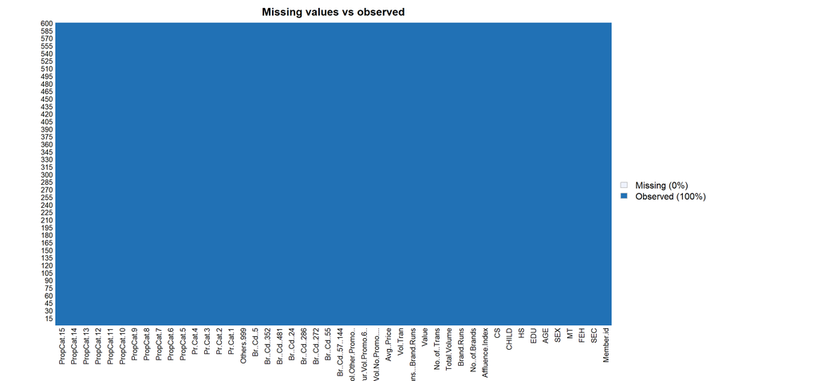

```r
# A visual take on the missing values might be helpful: the Amelia package has a special plotting function missmap() that will plot dataset and highlight missing values:
library(Amelia)
missmap(Soap_Data, main = "Missing values vs observed")
```

** There is no data missing in our dataset

- The Member.id variable is unique identifier for each household so I will Convert it to the row names, as this will later help me in visualizing the clusters

```r
# set row names to the Member.id
rownames(Soap_Data) <- Soap_Data$Member.id

# Drop the name column as it is now just redundant information
Soap_Data[,1] = NULL
```

- As the data consists of percentage of total volume purchased by the households, taking percentage and normalizing them will not give actual loyalty of the household to one brand. For example, if I consider 20% of 1000 volume purchased and 20% of 500 volume purchased the scale will differ for ‘max to one brand’ variable. That’s why initially all the percentages are converted into actual volumes before normalizing the data.

### Q 1 - A

### Clusters based on “Purchase Behavior” variables

```r
# first I need to convert factor variables to numeric as here from % to decimals
a <- Soap_Data[19:45] %>% mutate_each(funs(as.numeric(gsub("%", "", ., fixed = TRUE))/100))
Soap <- cbind(Soap_Data[1:18],a)

# Second, Sub setting purchase behavior variables
P_Behavior<-Soap[,11:30]
head(P_Behavior)
```

```
##         No..of.Brands Brand.Runs Total.Volume No..of..Trans  Value
## 1010010             3         17         8025            24  818.0
## 1010020             5         25        13975            40 1681.5
## 1014020             5         37        23100            63 1950.0
## 1014030             2          4         1500             4  114.0
## 1014190             3          6         8300            13  591.0
## 1017020             3         26        18175            41 1705.5
##         Trans...Brand.Runs Vol.Tran Avg..Price Pur.Vol.No.Promo....
## 1010010               1.41   334.38      10.19                 1.00
## 1010020               1.60   349.38      12.03                 0.89
## 1014020               1.70   366.67       8.44                 0.94
## 1014030               1.00   375.00       7.60                 1.00
## 1014190               2.17   638.46       7.12                 0.61
## 1017020               1.58   443.29       9.38                 1.00
##         Pur.Vol.Promo.6.. Pur.Vol.Other.Promo.. Br..Cd..57..144 Br..Cd..55
```

[output cut: 20 more lines]

```r
# Then find out the total volumes for each brand category
volume <- function(x){
return(x*P_Behavior$Total.Volume)
}
vol<-as.data.frame(lapply(P_Behavior[9:20],volume))
```

- For brand loyalty indicators, I have data for percent of purchases devoted to major brands (i.e. is a customer a total devotee of brand A?), a catch-all variable for percent of purchases devoted to other smaller brands (to reduce complexity of analysis), and (3) a derived variable that indicates the maximum share devoted to any one brand. Since CRISA is compiling this data for general marketing use, and not on behalf of one particular brand,I can say a customer who is fully devoted to brand A is similar to a customer fully devoted to brand B - both are fully loyal customers in their behavior, But if we include all the brand shares in the clustering, the analysis will treat those two customers as very different, So I will use only the derived variable for maximum purchase share for a brand, any brand, plus “max.brand.ind” and the “other.brand.ind,” along with the purchase.ind (for volume, frequency, etc.). I will not use the individual values - “brand.ind.”

```r
Purchase_Behavior <- P_Behavior[,1:8]
Purchase_Behav <- cbind(Purchase_Behavior,vol)
head(Purchase_Behav)
```

```
##         No..of.Brands Brand.Runs Total.Volume No..of..Trans  Value
## 1010010             3         17         8025            24  818.0
## 1010020             5         25        13975            40 1681.5
## 1014020             5         37        23100            63 1950.0
## 1014030             2          4         1500             4  114.0
## 1014190             3          6         8300            13  591.0
## 1017020             3         26        18175            41 1705.5
##         Trans...Brand.Runs Vol.Tran Avg..Price Pur.Vol.No.Promo....
## 1010010               1.41   334.38      10.19              8025.00
## 1010020               1.60   349.38      12.03             12437.75
## 1014020               1.70   366.67       8.44             21714.00
## 1014030               1.00   375.00       7.60              1500.00
## 1014190               2.17   638.46       7.12              5063.00
## 1017020               1.58   443.29       9.38             18175.00
##         Pur.Vol.Promo.6.. Pur.Vol.Other.Promo.. Br..Cd..57..144 Br..Cd..55
```

[output cut: 20 more lines]

```r
Purchase_Behav$max <- apply(Purchase_Behav[,12:19], 1, max)
head(Purchase_Behav)
```

```
##         No..of.Brands Brand.Runs Total.Volume No..of..Trans  Value
## 1010010             3         17         8025            24  818.0
## 1010020             5         25        13975            40 1681.5
## 1014020             5         37        23100            63 1950.0
## 1014030             2          4         1500             4  114.0
## 1014190             3          6         8300            13  591.0
## 1017020             3         26        18175            41 1705.5
##         Trans...Brand.Runs Vol.Tran Avg..Price Pur.Vol.No.Promo....
## 1010010               1.41   334.38      10.19              8025.00
## 1010020               1.60   349.38      12.03             12437.75
## 1014020               1.70   366.67       8.44             21714.00
## 1014030               1.00   375.00       7.60              1500.00
## 1014190               2.17   638.46       7.12              5063.00
## 1017020               1.58   443.29       9.38             18175.00
##         Pur.Vol.Promo.6.. Pur.Vol.Other.Promo.. Br..Cd..57..144 Br..Cd..55
```

[output cut: 20 more lines]

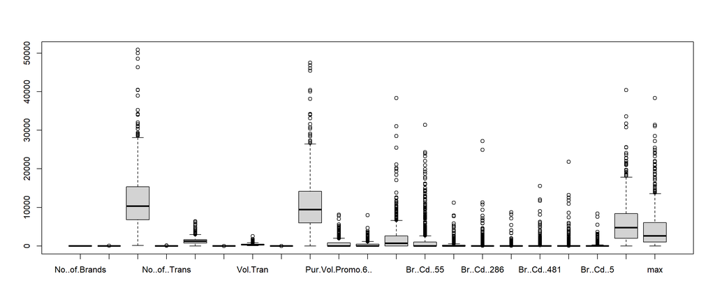

```r
boxplot(Purchase_Behav)
```

```r
# Note that the range of most of variables is wildly different and I do not want the algorithm to depend on an arbitrary variable unit so, I will Scale the data using function scale.
Soap_scaled <- scale(Purchase_Behav[c(1:8,20,21)])
head(Soap_scaled)
```

```
##         No..of.Brands Brand.Runs Total.Volume No..of..Trans      Value
## 1010010    -0.4030277  0.1200727   -0.5005898    -0.4104681 -0.5881031
## 1010020     0.8630280  0.8895639    0.2651391     0.5076339  0.3896410
## 1014020     0.8630280  2.0438006    1.4394712     1.8274054  0.6936645
## 1014030    -1.0360556 -1.1303505   -1.3403176    -1.5580955 -1.3852447
## 1014190    -0.4030277 -0.9379777   -0.4651989    -1.0416632 -0.8451360
## 1017020    -0.4030277  0.9857502    0.8056536     0.5650152  0.4168163
##         Trans...Brand.Runs   Vol.Tran  Avg..Price Others.999        max
## 1010010         -0.4636969 -0.3242918 -0.43944366 -0.3870628 -0.2762890
## 1010020         -0.3907514 -0.2639930  0.05217678  0.6565013 -0.4817448
## 1014020         -0.3523590 -0.1944886 -0.90701745  0.4747587  1.5386952
## 1014030         -0.6211057 -0.1610026 -1.13145287 -1.0949914 -0.6803394
## 1014190         -0.1719147  0.8980852 -1.25970168  0.1059753 -0.6310902
## 1017020         -0.3984298  0.1135176 -0.65586353  1.6977747 -0.5762018
```

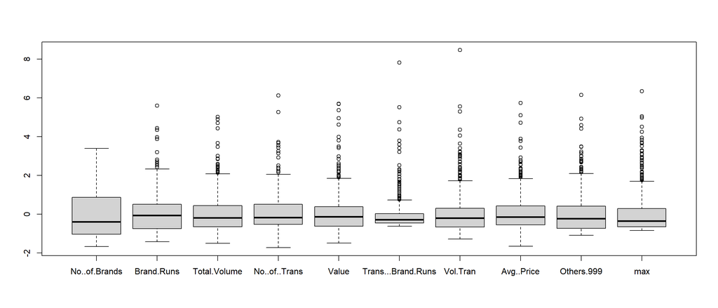

```r
boxplot(Soap_scaled)
```

### Using K-mean clustring for Purchase Behavior clustering

** Checking the best k using “silhouette” method

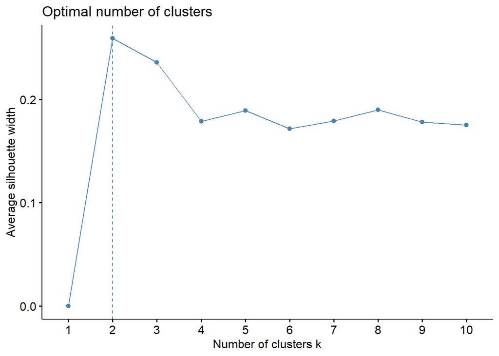

```r
fviz_nbclust(Soap_scaled, kmeans, method = "silhouette")
```

- The above graph shows that the k =2 is the best number of clusters

### I can use k= 2 for initial clustering

```r
set.seed(123)
k2 <- kmeans(Soap_scaled, centers = 2, nstart = 25) # k = 2, number of restarts = 25
k2$centers
```

```
##   No..of.Brands Brand.Runs Total.Volume No..of..Trans      Value
## 1     0.6210854  0.8049601    0.9414897     0.8834668  0.9844774
## 2    -0.2900423 -0.3759105   -0.4396688    -0.4125725 -0.4597437
##   Trans...Brand.Runs   Vol.Tran  Avg..Price Others.999        max
## 1        -0.11388393  0.2939720  0.02366772  0.8696763  0.2616040
## 2         0.05318296 -0.1372828 -0.01105265 -0.4061324 -0.1221672
```

```r
k2$size
```

```
## [1] 191 409
```

```r
#Screen Plot - Check for the optimal number of clusters given the data
wss <- (nrow(Soap_scaled)-1)*sum(apply(Soap_scaled,2,var))
wss
```

```
## [1] 5990
```

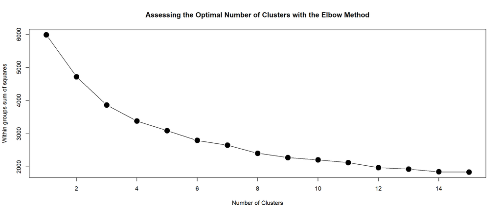

```r
for (i in 2:15)
  wss[i] <- sum(kmeans(Soap_scaled,
                       centers=i)$withinss)
plot(1:15, wss, type="b", xlab="Number of Clusters",
     ylab="Within groups sum of squares",
     main="Assessing the Optimal Number of Clusters with the Elbow Method",
     pch=19, cex=2)
```

* Running the k-means using algorithm using k = 3.

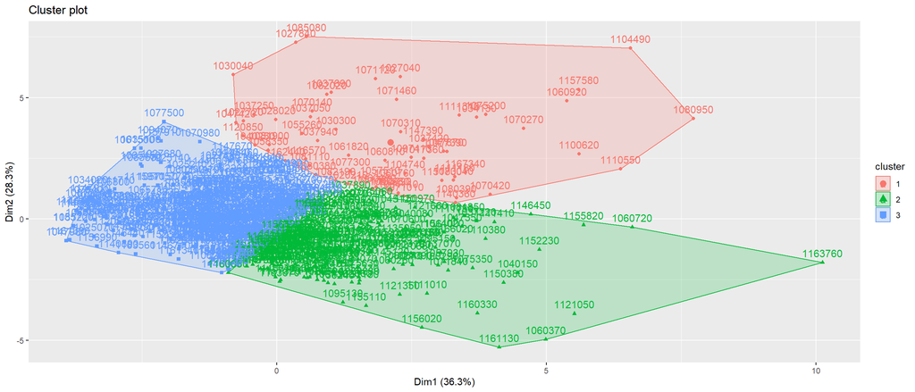

```r
set.seed(123)
k3 <- kmeans(Soap_scaled, centers = 3, nstart = 25) # k = 3, number of restarts = 25
fviz_cluster(k3, data = Soap_scaled) # Visualize the output
```

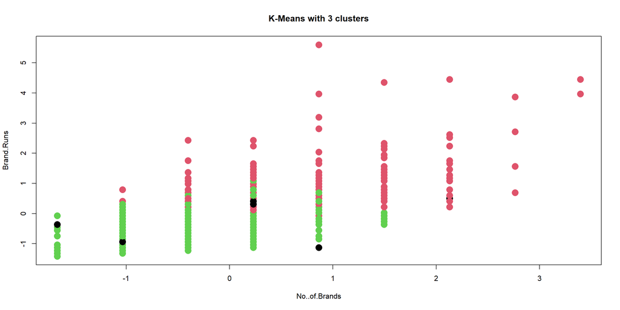

```r
set.seed(123)
# Plot results
plot(Soap_scaled, col =(k3$cluster) ,
     main="K-Means with 3 clusters",
     pch=16, cex=2)
```

### It is more obvious when I plot the Heat map

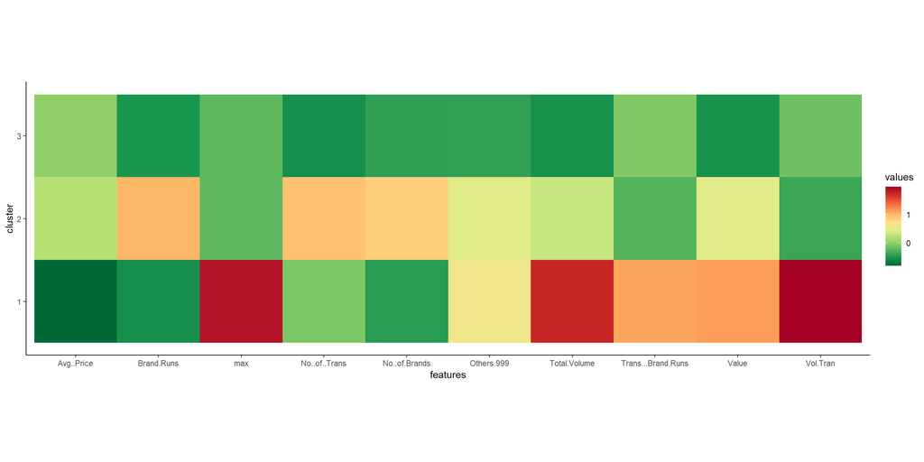

```r
#Building a data frame with the values of the center and creating a variable with the number of the cluster
#Creating the reshape database
center <- k3$centers
cluster <- c(1:3)
center_Soap <- data.frame(cluster, center)
center_reshape <- gather(center_Soap, features, values,No..of.Brands, Brand.Runs, Total.Volume, No..of..Trans, Value, Trans...Brand.Runs, Vol.Tran, Avg..Price, Others.999, max)

set.seed(123)
library(RColorBrewer)
# Creating the palette of colors I will use to plot the heat map
hm.palette <-colorRampPalette(rev(brewer.pal(10, 'RdYlGn')),space='Lab')

# Plot the heat map
ggplot(data = center_reshape, aes(x = features, y = cluster, fill = values)) +
    scale_y_continuous(breaks = seq(1, 3, by = 1)) +
    geom_tile() +
    coord_equal() +
    scale_fill_gradientn(colours = hm.palette(90)) +
    theme_classic()
```

```r
k3$centers
```

```
##   No..of.Brands Brand.Runs Total.Volume No..of..Trans      Value
## 1    -0.4532681 -0.5410179    1.7591224   -0.07984208  1.1369092
## 2     0.8442252  0.9871788    0.3228188    0.93032437  0.5094311
## 3    -0.4238137 -0.4935104   -0.5254750   -0.54595663 -0.5209862
##   Trans...Brand.Runs   Vol.Tran  Avg..Price Others.999        max
## 1         1.09277940  1.9749315 -0.79950729  0.6207403  1.8799807
## 2        -0.25546570 -0.3784341  0.22750042  0.4967272 -0.2151306
## 3        -0.05146576 -0.1432149  0.01317574 -0.4162553 -0.2238281
```

```r
k3$size
```

```
## [1]  63 202 335
```

## Q 1 - B

## Clusters based on “Basis for Purchase”

- The variables used are: Pur_vol_no_promo, Pur_vol_promo_6, Pur_vol_other, all price categories, selling propositions 5 and 14 (most people seemed to be responding to one or the other of these promotions/propositions).
- we dropped all the other selling propositions except PropCat.5 and PropCat.14

```r
set.seed(123)
# Sub setting basis of purchase variables
P_Basis<-Soap[,c(13,19:21,31:35,44)]
# Finding out the total volumes for each brand category
volume2 <- function(x){
return(x*P_Basis$Total.Volume)
}
Pur_Basis<-as.data.frame(lapply(P_Basis[2:10],volume2))
```

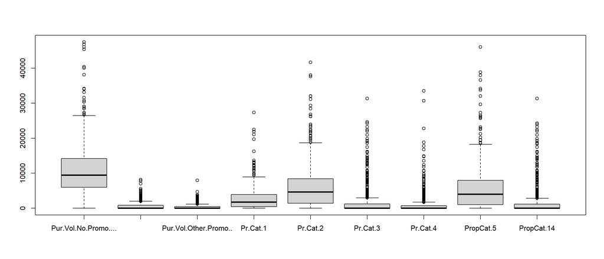

```r
boxplot(Pur_Basis)
```

```r
# Note that the data show some variations in their ranges so, I will Scale the data using function scale.
Basis_scaled <- scale(Pur_Basis)
head(Basis_scaled)
```

```
##      Pur.Vol.No.Promo.... Pur.Vol.Promo.6.. Pur.Vol.Other.Promo..      Pr.Cat.1
## [1,]           -0.3943558        -0.5574329            -0.5116939 -0.2794416143
## [2,]            0.1983882         0.7686897            -0.1252184  0.3854838369
## [3,]            1.4444233        -0.1190296             0.7659568 -0.0003808082
## [4,]           -1.2708284        -0.5574329            -0.5116939 -0.8355295851
## [5,]           -0.7922274         0.5452179             2.2427218 -0.8355295851
## [6,]            0.9690461        -0.5574329            -0.5116939  0.3691393848
##        Pr.Cat.2   Pr.Cat.3   Pr.Cat.4    PropCat.5 PropCat.14
## [1,] -0.2520866 -0.1988988 -0.1925159 -0.246319991 -0.1912455
## [2,]  0.2625352 -0.1496659 -0.1056810  0.141979507 -0.1739337
## [3,]  0.2150992  2.5307700 -0.3687742 -0.000177325  2.5630697
## [4,] -0.8798374 -0.2317780 -0.3687742 -0.794776958 -0.2244217
## [5,] -0.9096612 -0.1716428  1.7406778  0.189311544 -0.1637435
## [6,]  0.3419310 -0.1463378  1.1709563  0.540123103 -0.1382100
```

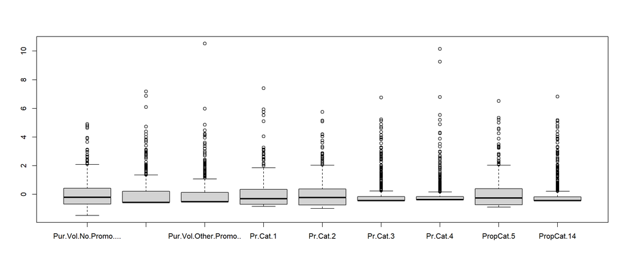

```r
boxplot(Basis_scaled)
```

## Using K-mean clustring for Bsis of Purchase clustering

### I will use k= 2 for initial clustering

```r
set.seed(123)
k2_Basis <- kmeans(Basis_scaled, centers = 2, nstart = 25) # k = 2, number of restarts = 25
k2_Basis$centers
```

```
##   Pur.Vol.No.Promo.... Pur.Vol.Promo.6.. Pur.Vol.Other.Promo..    Pr.Cat.1
## 1          -0.09819188       0.005863254           -0.07139671  0.06004765
## 2           0.88372689      -0.052769287            0.64257036 -0.54042887
##      Pr.Cat.2   Pr.Cat.3    Pr.Cat.4   PropCat.5 PropCat.14
## 1  0.04437383 -0.2919044  0.00610616  0.04579201 -0.2914596
## 2 -0.39936449  2.6271394 -0.05495544 -0.41212811  2.6231365
```

```r
k2_Basis$size
```

```
## [1] 540  60
```

** Using “elbow chart” to determine the best k

```r
set.seed(123)
#Screen Plot - Check for the optimal number of clusters given the data
wss <- (nrow(Basis_scaled)-1)*sum(apply(Basis_scaled,2,var))
wss
```

```
## [1] 5391
```

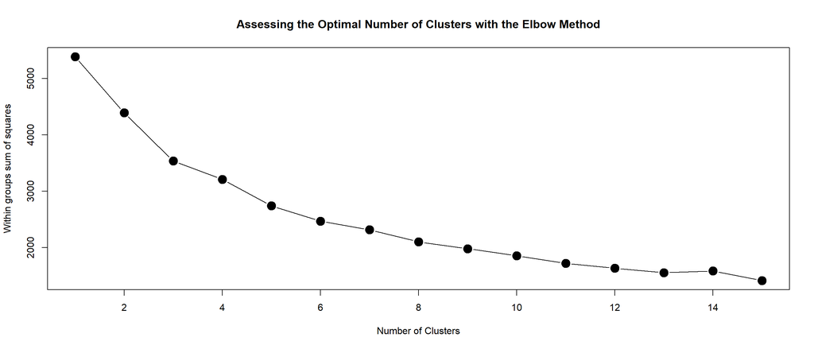

```r
for (i in 2:15)
  wss[i] <- sum(kmeans(Basis_scaled,
                       centers=i)$withinss)
plot(1:15, wss, type="b", xlab="Number of Clusters",
     ylab="Within groups sum of squares",
     main="Assessing the Optimal Number of Clusters with the Elbow Method",
     pch=19, cex=2)
```

* The above graph shows that the k =4 is the best number of clusters according to the Elbow method

- Running the k-means algorithm using k = 4.

```r
set.seed(123)
k4_Basis <- kmeans(Basis_scaled, centers = 4, nstart = 25) # k = 4, number of restarts = 25
```

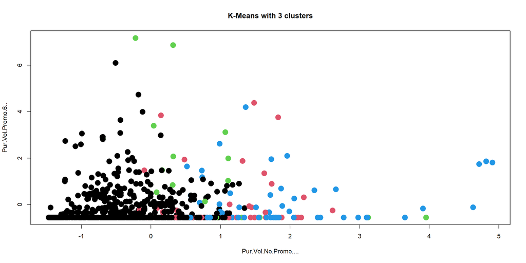

```r
set.seed(123)
# Plot results
plot(Basis_scaled, col =(k4_Basis$cluster) ,
     main="K-Means with 3 clusters",
     pch=16, cex=2)
```

- I can Visualize the characteristics of clusters

```r
set.seed(123)
library(GGally)
k4_Basis$centers
```

```
##   Pur.Vol.No.Promo.... Pur.Vol.Promo.6.. Pur.Vol.Other.Promo..   Pr.Cat.1
## 1           -0.3457880       -0.07470833            -0.1601836 -0.0230418
## 2            0.9348600       -0.01609218             0.6558030 -0.5597374
## 3            0.8999622        1.45047976            -0.2520301 -0.1886215
## 4            1.9082477        0.17141447             0.9056612  0.8400210
##     Pr.Cat.2   Pr.Cat.3    Pr.Cat.4  PropCat.5 PropCat.14
## 1 -0.1628319 -0.2754150 -0.15046944 -0.2167917 -0.2752208
## 2 -0.4650718  2.8059911 -0.01396919 -0.4645329  2.7978842
## 3 -0.6350319 -0.2551774  4.30073146  1.8373534 -0.2503970
## 4  2.1907724 -0.1863504 -0.17718417  1.7818394 -0.1817715
```

```r
k4_Basis$size
```

```
## [1] 477  52  19  52
```

```r
# Storing the clusters in a data frame along with the data
cluster_B <- c(1,2,3,4)
Basis_clusters <- cbind(cluster_B, k4_Basis$centers)
ggparcoord((Basis_clusters),
           columns = 1:10, groupColumn = 1,
           showPoints = TRUE,
           alphaLines = 0.4
)
```

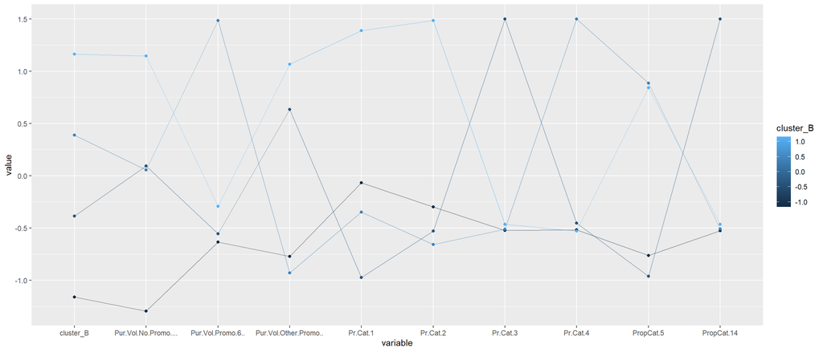

## Q 1 - C

## Clusters based on both purchase behavior and basis of purchase without the Demographic information

```r
set.seed(123)
# combining brand loyalty variables with basis of purchase variables
Both <-cbind(Soap_scaled, Basis_scaled)

### Using k= 2
k2_Both <- kmeans(Both, centers = 2, nstart = 25) # k = 2, number of restarts = 25
k2_Both$centers
```

```
##   No..of.Brands Brand.Runs Total.Volume No..of..Trans      Value
## 1     0.2164352  0.2341223    1.4068748     0.5719830  1.0982947
## 2    -0.0658716 -0.0712546   -0.4281793    -0.1740818 -0.3342636
##   Trans...Brand.Runs   Vol.Tran Avg..Price Others.999        max
## 1          0.3855428  0.9600910 -0.5017741  0.9208613  0.9152486
## 2         -0.1173391 -0.2922016  0.1527139 -0.2802621 -0.2785539
##   Pur.Vol.No.Promo.... Pur.Vol.Promo.6.. Pur.Vol.Other.Promo..    Pr.Cat.1
## 1             1.381328        0.25319675             0.5466865  0.32645153
## 2            -0.420404       -0.07705988            -0.1663828 -0.09935481
##     Pr.Cat.2   Pr.Cat.3   Pr.Cat.4  PropCat.5 PropCat.14
## 1  0.7936581  0.8004307  0.4524234  0.7968325  0.7975701
## 2 -0.2415481 -0.2436093 -0.1376941 -0.2425142 -0.2427387
```

```r
k2_Both$size
```

```
## [1] 140 460
```

- I can Visualize the characteristics of clusters

```r
# Store the clusters in a data frame along with the data
cluster_Both <- c(1,2)
Both_clusters <- cbind(cluster_Both, k2_Both$centers)
ggparcoord((Both_clusters),
           columns = 1:20, groupColumn = 1,
           showPoints = TRUE,
           alphaLines = 0.3
)
```

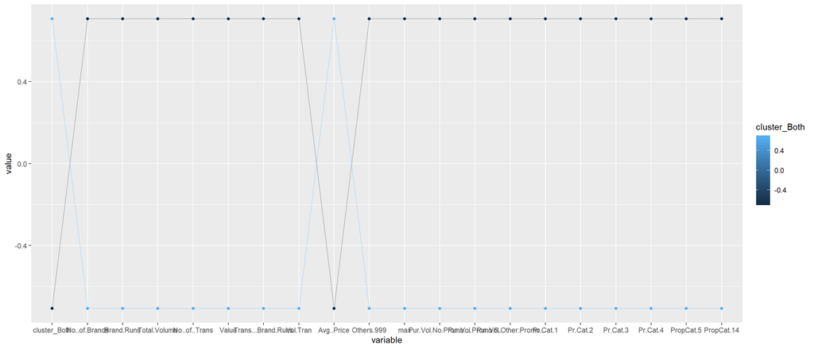

* I can add the demographic information

```r
set.seed(123)
# adding Demographic variables
Demo <- Soap[1:10]
demo_scaled <- scale(Demo)
Both_Demo <- cbind(demo_scaled,Both)

### we will use k= 2
k2_Both_Demo <- kmeans(Both_Demo, centers = 2, nstart = 25) # k = 2, number of restarts = 25
k2_Both_Demo$centers
```

```
##           SEC       FEH         MT        SEX         AGE        EDU         HS
## 1  0.03359705  0.230683  0.2434082  0.3426209  0.07494281  0.2359891  0.2329374
## 2 -0.26284751 -1.804756 -1.9043115 -2.6805048 -0.58631729 -1.8462679 -1.8223924
##        CHILD         CS Affluence.Index No..of.Brands Brand.Runs Total.Volume
## 1 -0.1855333  0.2347099       0.1906638     0.0967311  0.1119366    0.1350305
## 2  1.4515254 -1.8362598      -1.4916636    -0.7567786 -0.8757394   -1.0564151
##   No..of..Trans      Value Trans...Brand.Runs    Vol.Tran  Avg..Price
## 1     0.1543933  0.1299308         0.04439609  0.01489359 -0.02360935
## 2    -1.2079004 -1.0165176        -0.34733408 -0.11652047  0.18470841
##    Others.999         max Pur.Vol.No.Promo.... Pur.Vol.Promo.6..
## 1  0.09980655  0.07230177            0.1295058         0.0555561
## 2 -0.78083949 -0.56565504           -1.0131928        -0.4346448
##   Pur.Vol.Other.Promo..    Pr.Cat.1    Pr.Cat.2    Pr.Cat.3    Pr.Cat.4
## 1            0.03714307  0.06653001  0.09301779  0.02870228  0.03970347
## 2           -0.29058990 -0.52049946 -0.72772744 -0.22455310 -0.31062128
##     PropCat.5  PropCat.14
## 1  0.08749423  0.02775365
## 2 -0.68451371 -0.21713153
```

```r
k2_Both_Demo$size
```

```
## [1] 532  68
```

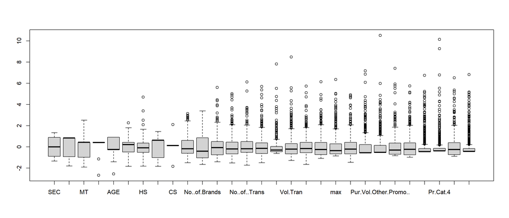

```r
boxplot(Both_Demo)
```

- I can Visualize the characteristics of clusters

```r
# Store the clusters in a data frame along with the data
cluster_Both_Demo <- c(1,2)
Both_Demo_clusters <- cbind(cluster_Both_Demo, k2_Both_Demo$centers)
ggparcoord((Both_Demo_clusters),
           columns = 1:30, groupColumn = 1,
           showPoints = TRUE,
           alphaLines = 0.3
)
```

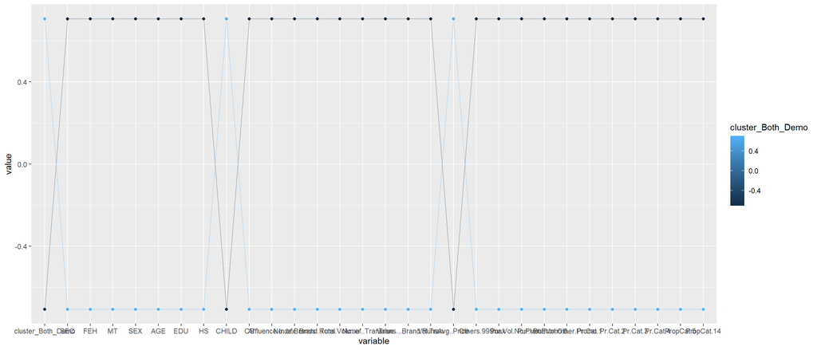

## Q 2. ## Best cluster approach